# Geospatial - Assignment 2

Moritz Peist

Noemi Lucchi

Simon Vellin

[figure not shown]

# Methodology & general code

In this notebook, we combine various sources from [Natural Earth](https://www.naturalearthdata.com) to produce different types of plots. Throughout, we implement the methodologies recently discussed in class, such as distance computation, spatial merging, and filtering. Contentwise, we follow the assignment’s instructions and provide the requested plots.

First we load the needed packages:

```r
# Main tidyverse (includes ggplot2)
library(tidyverse)

# Spatial packages
library(sf)
library(spData)
library(tidyverse)
library(units)
library(lwgeom)
library(gridExtra)
library(readxl)
```

# Exercise 1: World and airports

We decided to use the [Natural Earth airports dataset](https://www.naturalearthdata.com/downloads/10m-cultural-vectors/airports/) to plot the airports on a world map for this task. We downloaded all the data and load it from disk for speed and efficiency though a [package](https://cran.r-project.org/web/packages/rnaturalearth/vignettes/rnaturalearth.html) would exist to download the data directly.

## 1.1. Map of total population by country

### Data Loading

In order to plot the distribution of the total population by country, we import data from [Natural Earth Admin 0 - Countries](https://www.naturalearthdata.com/downloads/10m-cultural-vectors/10m-admin-0-countries/) dataset which contains both the geometries of the countries and the corresponding population estimate.

```r
sf.world <- st_read("data/ne_10m_admin_0_countries", crs = 4326) %>%
  # Rename columns in the world dataset to make joining / operations easier
  rename(
    iso_a2 = ISO_A2,
    continent = CONTINENT
  )
```

We do not need any extensive data wrangling for this plot, as the data is already in a suitable format. Thus, we just go ahead and plot the total population by country.

### Plotting

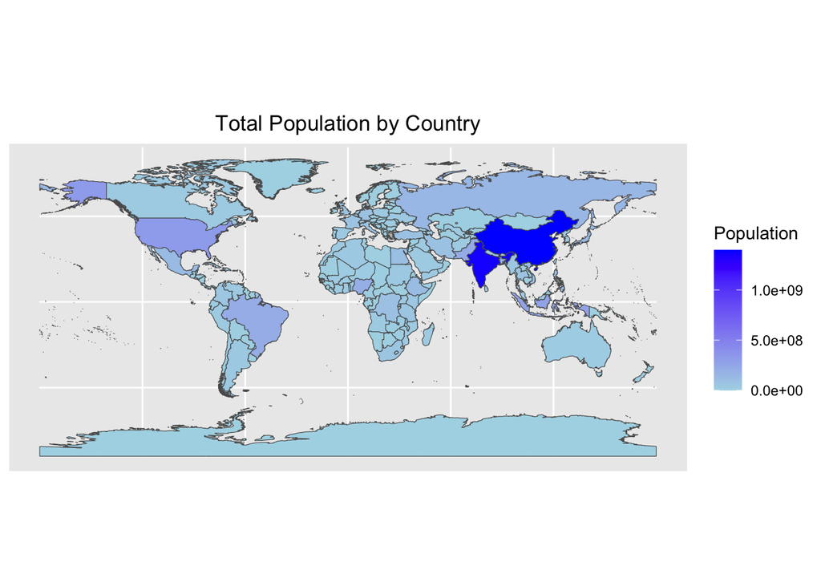

```r
# Population in absolute terms
ggplot() +
  geom_sf(data = sf.world, aes(fill = POP_EST)) +
  scale_fill_gradient(name = "Population", low = "lightblue", high = "blue") +
  labs(title = "Total Population by Country", fill = "Population") +
  theme(
    plot.title = element_text(hjust = 0.5)
  )
```

## 1.2. Histogram of country population distribution by continent

### Data Loading

As for the previous plot, we only need the world data.

### Data Wrangling

First, we filter out countries without a continent and repair invalid polygons in case there are any. For a coarse-granular overview, we define population ranges by labeling countries based on their population size. After categorizing the countries into these ranges, we calculate the number of countries in each population range, grouped by continent. This gives us a summary of the distribution of countries by population size within each continent. Finally, we ensure that the population ranges are ordered increasingly (“0-10M”, “10M-50M”, “50M-100M”, “100M-500M”, “500M+”) by using the R factor datatype.

```r
# Filter countries with NA continents and repair invalid polygons
sf.world <- sf.world %>%
  filter(!is.na(continent)) %>%
  # Repair invalid polygons
  st_make_valid() %>%
  # Create the population ranges as factors
  mutate(pop_range = factor(
    case_when(
      POP_EST < 1e7 ~ "0-10M",
      POP_EST >= 1e7 & POP_EST < 5e7 ~ "10M-50M",
      POP_EST >= 5e7 & POP_EST < 1e8 ~ "50M-100M",
      POP_EST >= 1e8 & POP_EST < 5e8 ~ "100M-500M",
      TRUE ~ "500M+"
    ),
    levels = c("0-10M", "10M-50M", "50M-100M", "100M-500M", "500M+")
  ))

# Calculate the number of countries per range + country
population_distribution <- sf.world %>%
  group_by(continent, pop_range) %>%
  summarise(country_count = n(), .groups = "drop")
```

### Plotting

Now we start with a coarse granular plot to get an initial overview of the data.

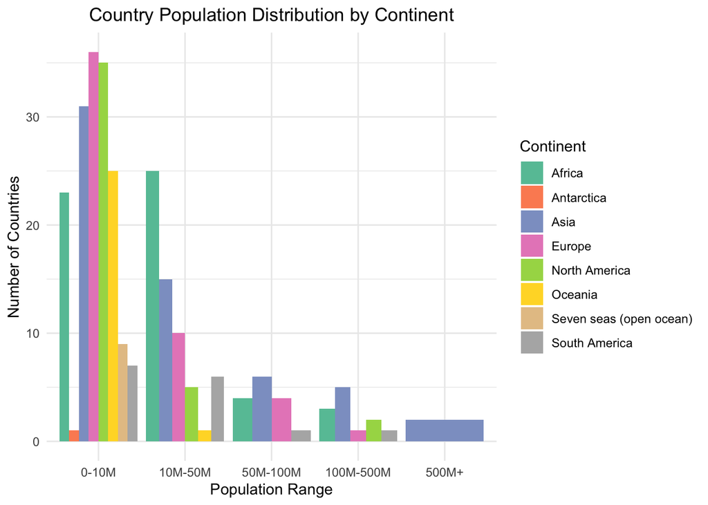

```r
ggplot(population_distribution, aes(x = pop_range, y = country_count, fill = continent)) +
  geom_histogram(stat = "identity", position = "dodge") +
  scale_fill_brewer(palette = "Set2") +
  labs(
    title = "Country Population Distribution by Continent", x = "Population Range",
    y = "Number of Countries", fill = "Continent"
  ) +
  theme_minimal() +
  theme(
    plot.title = element_text(hjust = 0.5)
  )
```

We plot the same data but with a more detailed view to better understand the distribution of countries by population size within each continent as asked by the task. However, we exclude Seven Seas and Antarctica as they contribute relatively little information. Moreover, we use a log-scale by population size, since country populations vary hugely, also by continent as this allows us to better visualize the data.

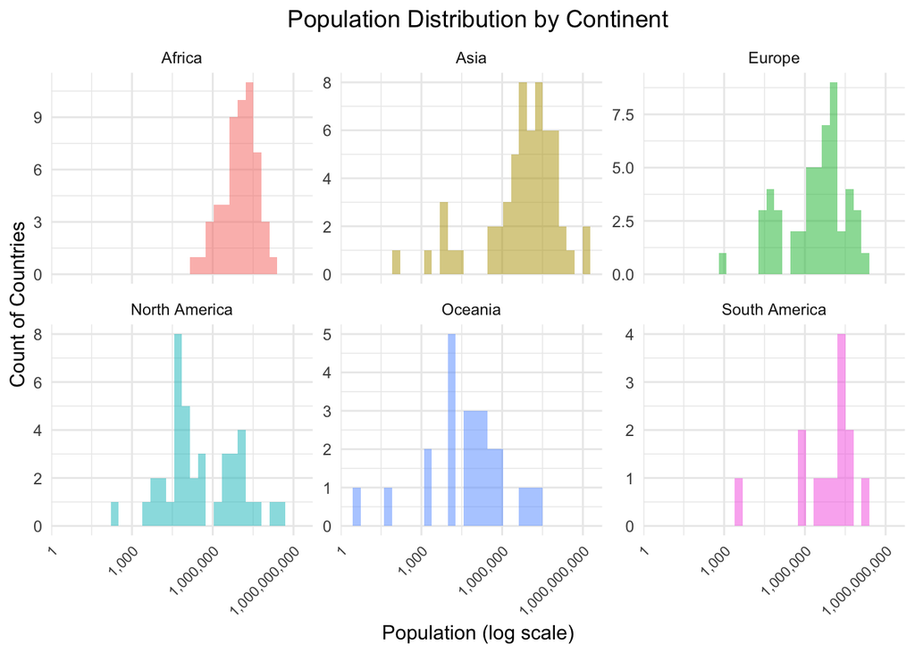

```r
# Filter out Seven Seas and Antarctica
sf.world_filt <- sf.world %>%
  mutate(
    continent = case_when(
      continent %in% c("Seven seas (open ocean)", "Antarctica") ~ NA_character_,
      TRUE ~ continent
    )
  ) %>%
  filter(!is.na(continent))

# Create a proper histogram using the continuous population data
ggplot(sf.world_filt, aes(x = POP_EST, fill = continent)) +
  geom_histogram(position = "identity", alpha = 0.5, bins = 30) +
  scale_x_log10(labels = scales::comma) + # Use log scale due to large population range
  facet_wrap(~continent, scales = "free_y") + # Separate panels for each continent
  labs(
    title = "Population Distribution by Continent",
    x = "Population (log scale)",
    y = "Count of Countries",
    fill = "Continent"
  ) +
  theme_minimal() +
  theme(
    legend.position = "none", # Remove legend since we're using facets
    plot.title = element_text(hjust = 0.5),
    axis.text.x = element_text(
      angle = 45, # Rotate labels
      hjust = 1, # Align rotated labels
      size = 8 # Smaller font size
    )
  )
```

## 1.3. Histogram of country-level average distances between locations and airports by continent.

### Data Loading

In addition to Natural Earth’s population data, we incorporate also the datasets for [populated places (simple)](https://www.naturalearthdata.com/downloads/10m-cultural-vectors/10m-populated-places/) (sf.pop) and [airports](https://www.naturalearthdata.com/downloads/10m-cultural-vectors/airports/) (sf.airports).

```r
sf.airports <- st_read("data/ne_10m_airports", crs = 4326)
sf.pop <- st_read("data/ne_10m_populated_places_simple", crs = 4326)
```

### Data Wrangling

This code computes and plots the average distances between populated places and airports across different continents, using two approaches: first, by computing the minimum distance for each city and averaging these values per country, and second, by directly averaging all city-airport distances within a country to allow for range-based visualization. Cities from the sf.pop dataset are joined with country and continent metadata from the sf.world dataset, while airports from sf.airports are joined with country metadata. Distances are calculated at two levels: in “distances” we compute the minimum distance from each city to the nearest airport and average these values per country, while in “distances_country” we directly average all city-airport distances within a country. Then we categorize “distances_country” into ranges (e.g., <50 km, <100 km) to ensure a better visualization. The first plot shows the distribution of city-level average distances by continent, while the second plot shows the number of countries in each distance range, grouped by continent.

**Important to note:** We only calculate the distance of the closest airport to each city per country. This means that we do not consider the distance of all populated places to all airports in a country, but only to the closest one. This is a simplification that allows us to reduce the number of distances to be computed and to avoid excessive granularity in the visualization, but also methodologically makes the most sense, otherwise distances in big countries will just be overboarding. Moreover, we add a buffer and use `st_nearest_feature` to avoid matching issues with coastal airports.

Next, we prepare the data for plotting the histograms of country-level average distances between locations and airports by continent.

```r
# 1. Prepare cities and airports with country metadata
cities_with_countries <- sf.world %>%
  st_drop_geometry() %>% # Drop geometry to avoid conflicts
  select(iso_a2, continent) %>% # Select relevant columns
  left_join( # Join with cities dataset
    sf.pop %>% select(name, iso_a2, ne_id, geometry),
    by = "iso_a2"
  ) %>%
  st_as_sf() %>% # Convert to sf object
  drop_na() # Remove rows with missing values

# 2. Create a small buffer around countries to catch coastal points
# Buffer size in degrees (since CRS is 4326)
buffer_size <- 0.01 # roughly 1km at the equator

airports_with_countries <- sf.airports %>%
  select(name, geometry) %>% # Select relevant columns
  # Join with buffered country polygons
  st_join(
    sf.world %>% # Join with country metadata
      select(iso_a2, continent) %>%
      st_buffer(dist = buffer_size),
    join = st_nearest_feature, # Use nearest feature instead of intersection
    left = TRUE # Keep all airports
  )

# 2. Calculate closest airport distance per city, then average per country
distances <- cities_with_countries %>%
  # For each country group:
  group_by(continent, iso_a2, ne_id) %>%
  summarise(
    avg_closest_distance_km = {
      current_iso <- cur_group()$iso_a2 # Capture current country code
      country_airports <- airports_with_countries %>%
        filter(iso_a2 == current_iso) # Filter airports for this country
      if (nrow(country_airports) == 0) {
        NA_real_ # Return NA if no airports exist
      } else {
        # Compute closest airport distance for each city in the country
        closest_distances <- st_distance(
          geometry, # City geometries
          country_airports # Airports in the current country
        ) %>%
          apply(1, min) %>% # Find minimum distance per city (row)
          as.numeric() / 1000 # Convert meters to kilometers
        mean(closest_distances, na.rm = TRUE)
      }
    }
  ) %>%
  ungroup() %>% # Remove grouping
  drop_na() # Remove countries with no airports
```

### Plotting

Now, we plot the histogram of country level average distances between locations and airports by continent - as asked for by the exercise. Once again we filter out the Seven Seas and Antarctica as they do not contribute much information and since only 16 airports are impacted by this anyways.

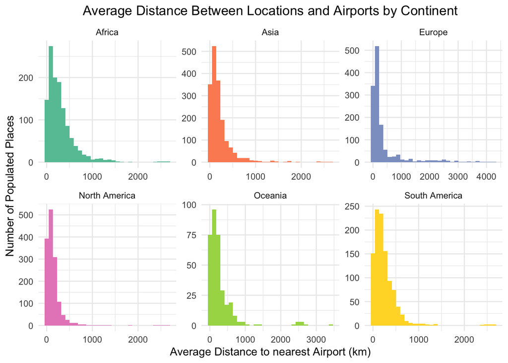

```r
# Filter out Seven Seas and Antarctica
distances_filt <- distances %>%
  mutate(
    continent = case_when(
      continent %in% c("Seven seas (open ocean)", "Antarctica") ~ NA_character_,
      TRUE ~ continent
    )
  ) %>%
  filter(!is.na(continent))

# Plot 1
ggplot(distances_filt, aes(x = avg_closest_distance_km, fill = continent)) +
  geom_histogram(bins = 30, position = "dodge") +
  scale_fill_brewer(palette = "Set2") +
  labs(
    title = "Average Distance Between Locations and Airports by Continent",
    x = "Average Distance to nearest Airport (km)", y = "Number of Populated Places", fill = "Continent"
  ) +
  facet_wrap(~continent, scales = "free") +
  theme_minimal() +
  theme(
    legend.position = "none", # Remove legend since we're using facets
    plot.title = element_text(hjust = 0.5)
  )
```

Since we have these issues, let’s look at the airports also in a more coarse-granular way to get a better understanding of the data (once again we exclude Seven Seas and Antarctica).

```r
# 3. Calculate average distances at country level. With this approach, instead of
# computing the closest airport distance per city and then averaging per country,
# we compute all the distances within a country and then we average them.

# Basically, same code as before, so no extensive comments
distances_country <- cities_with_countries %>%
  group_by(continent, iso_a2) %>% # Removed ne_id to group at country level
  summarise(
    avg_closest_distance_km = {
      current_iso <- cur_group()$iso_a2
      country_airports <- airports_with_countries %>%
        filter(iso_a2 == current_iso)
      if (nrow(country_airports) == 0) {
        NA_real_
      } else {
        closest_distances <- st_distance(
          geometry,
          country_airports
        ) %>%
          apply(1, min) %>%
          as.numeric() / 1000
        mean(closest_distances, na.rm = TRUE)
      }
    },
    country_name = first(name)
  ) %>%
  ungroup() %>%
  drop_na()

# 4. Create distance ranges – The previous step ensures a reasonable number of ranges.
# If we had used the distances computed earlier, the higher granularity would have resulted in an excessive number of ranges, leading to a poor visualization quality.
distances_ranges <- distances_country %>%
  mutate(
    distance_range = cut(avg_closest_distance_km,
      breaks = seq(0, max(avg_closest_distance_km, na.rm = TRUE) + 50, by = 50),
      labels = paste0("<", seq(50, max(avg_closest_distance_km, na.rm = TRUE) + 50, by = 50), "km"),
      include.lowest = TRUE
    ),
    continent = case_when(
      continent %in% c("Seven seas (open ocean)", "Antarctica") ~ NA_character_,
      TRUE ~ continent
    )
  ) %>%
  filter(!is.na(continent))
```

Let’s also plot the coarse-granular view of the data to get a better understanding of the distribution of average distances between locations and airports by continent.

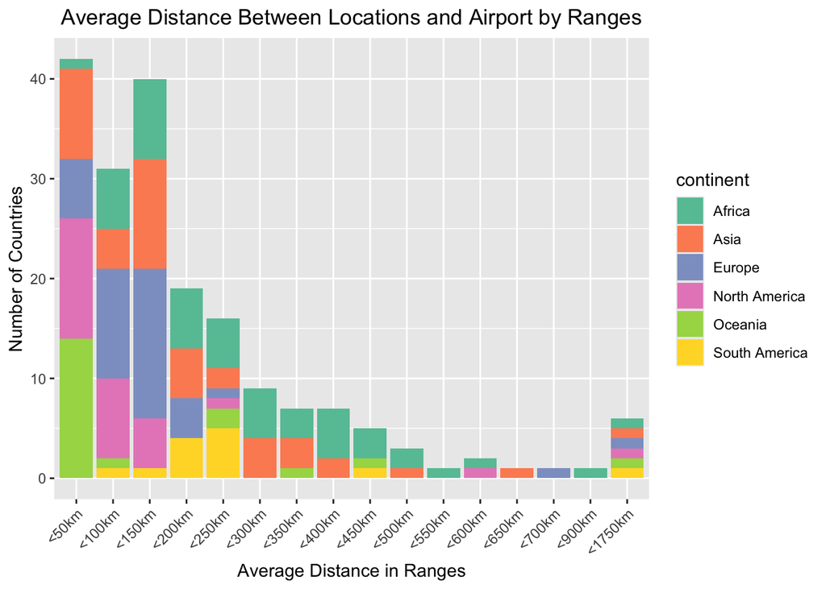

```r
ggplot(distances_ranges, aes(x = distance_range, fill = continent)) +
  geom_bar(position = "stack") +
  scale_fill_brewer(palette = "Set2") +
  theme(axis.text.x = element_text(angle = 45, hjust = 1)) +
  labs(
    title = "Average Distance Between Locations and Airport by Ranges",
    x = "Average Distance in Ranges", y = "Number of Countries", fill = "continent"
  ) +
  theme(
    plot.title = element_text(hjust = 0.5)
  )
```

# Exercise 2: Porteous data

This analysis explores agricultural market data in Africa using the Porteous dataset, which investigates trade costs and their impact on agricultural markets. The study examines the relationship between market locations, transportation infrastructure, and agricultural product prices across African countries.

The analysis is structured in three main parts:

1. Visualization of market locations across Africa
2. Analysis of markets’ accessibility through distance calculations
3. Investigation of price-distance relationships for different transportation modes

This work builds on Porteous (2019), who studied how trade costs affect agricultural storage and trade patterns in Africa. Understanding these relationships is crucial for identifying potential barriers to trade and market efficiency in African agricultural markets.

## 2.1. Map of markets in Africa

This section creates a visualization of market locations across Africa. The analysis combines three key geographical datasets:

- Administrative boundaries of African countries
- Road network data for transportation infrastructure
- Market location coordinates from the Porteous dataset

The resulting map will help us understand the spatial distribution of agricultural markets and their relationship to national boundaries. This visualization is particularly important for identifying potential clusters of markets and areas that might be underserved.

### Data Loading

The data loading process integrates three essential geographical datasets using appropriate coordinate reference systems (CRS). We use EPSG:4326, which is the standard WGS84 geographic coordinate system, ensuring consistent spatial representation across all datasets. The data includes:

1. World administrative boundaries for defining African countries
2. African road network data for understanding transportation infrastructure
3. Market coordinates from the Porteous dataset, converted to spatial features

Converting the market coordinates to spatial features (sf) allows us to perform spatial operations and create meaningful visualizations. The careful attention to coordinate systems is crucial for accurate geographical analysis.

```r
# Clean enviornment first
rm(list = ls())

# Data Loading (with correct CRS and long/lat conversions)
sf.world <- st_read("data/ne_10m_admin_0_countries", crs = "EPSG:4326")
sf.roads_africa <- st_read("data/ne_10m_roads", crs = "EPSG:4326")
sf.markets <- st_as_sf(
  read_excel("data/porteous_data/1.-Price--Production--and-Population-Data/MktCoords.xlsx"),
  coords = c("longitude", "latitude"),
  crs = "EPSG:4326"
)
```

### Plotting

The plotting phase creates a clear visualization of market locations within their geographical context. We use a layered approach to build the map, starting with country boundaries and adding market locations. The aesthetic choices are deliberate:

- Antiquewhite fill for countries provides a neutral background
- Gray borders help define country boundaries without overshadowing the main data
- Red and blue markers for markets ensure visibility while distinguishing them from the background
- Minimal theme removes unnecessary visual elements to focus attention on the data

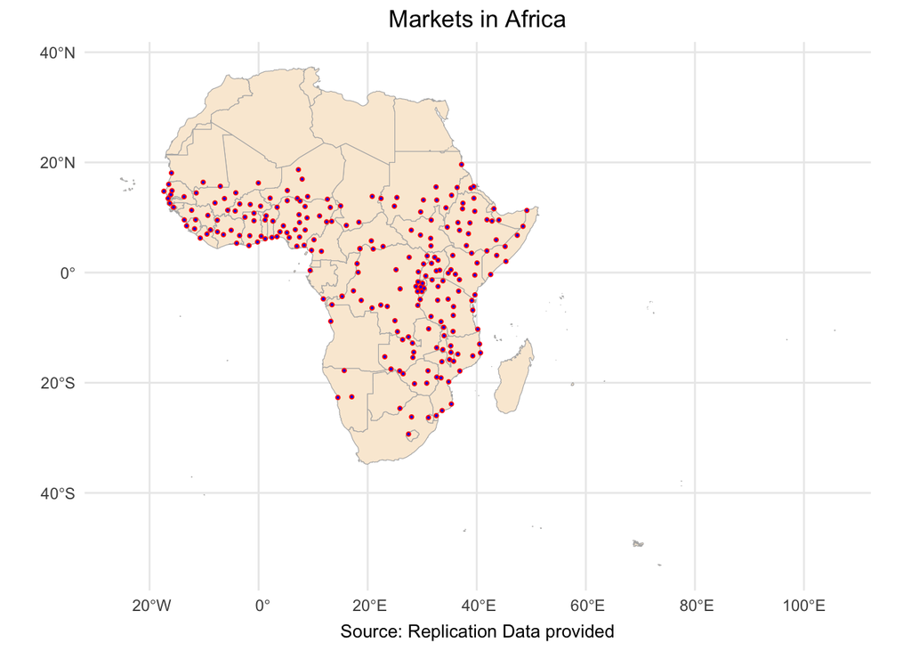

```r
# Plot
ggplot() +
  geom_sf(
    data = sf.world %>% filter(REGION_UN == "Africa"),
    fill = "antiquewhite", color = "gray70"
  ) +
  geom_sf(data = sf.markets, color = "red", size = 0.7, shape = 21, fill = "blue") +
  theme_minimal() +
  labs(
    title = "Markets in Africa",
    caption = "Source: Replication Data provided"
  ) +
  theme(
    legend.position = "none",
    plot.title = element_text(hjust = 0.5),
    plot.caption = element_text(size = 10, hjust = 0.5)
  )
```

## 2.2. Minimum distances

This section calculates the accessibility of markets by measuring their proximity to key transportation infrastructure. We examine three critical distance metrics:

1. Distance to coast: Important for international trade and port access
2. Distance to roads: Crucial for domestic distribution and market integration
3. Distance to airports: Relevant for high-value or time-sensitive agricultural products

These measurements help quantify the isolation or connectivity of each market, which can significantly impact trading costs and market efficiency. The analysis uses spatial analysis techniques to calculate the shortest distances between markets and each type of infrastructure.

### Data Loading

This subsection expands our dataset by incorporating additional infrastructure information. We load two new spatial datasets:

1. Airport locations across the globe
2. Coastline geometries

These datasets complement our existing market and road data, allowing us to compute comprehensive accessibility metrics. The careful organization of these spatial datasets ensures efficient processing in subsequent analysis steps.

```r
# Load data
sf.airports <- st_read("data/ne_10m_airports", crs = "EPSG:4326")
sf.coast <- st_read("data/ne_10m_coastline", crs = "EPSG:4326")
```

### Data Wrangling

This crucial data processing step involves several sophisticated spatial operations. The process:

1. Isolates African data to improve computational efficiency
2. Ensures geometric validity of spatial features
3. Calculates distance matrices between markets and various infrastructure points
4. Processes these matrices to find minimum distances

```r
# We isolate the African airports from our global data sets to stay efficient
sf.africa <- sf.world %>%
  filter(REGION_UN == "Africa") %>%
  filter(!st_is_valid(.)) %>%
  st_make_valid()

# Filter airports in Africa
sf.airports_africa <- sf.airports %>% st_filter(sf.africa)

# Data Wrangling - st_distance() returns a matrix with one row per market and one column per coast segment

# (i) Distance to Nearest Coast
dist_to_coast <- st_distance(sf.markets, sf.coast)
# For each market (row) we take the minimum distance:
min_coast_dist <- apply(dist_to_coast, 1, min)

# (ii) Distance to Nearest Road
dist_to_roads <- st_distance(sf.markets, sf.roads_africa)
min_road_dist <- apply(dist_to_roads, 1, min)

# (iii) Distance to Nearest Airport
dist_to_airports <- st_distance(sf.markets, sf.airports_africa)
min_airport_dist <- apply(dist_to_airports, 1, min)

# Add the computed distances to the markets data
sf.markets <- sf.markets %>%
  mutate(
    min_coast_dist   = as.numeric(min_coast_dist),
    min_road_dist    = as.numeric(min_road_dist),
    min_airport_dist = as.numeric(min_airport_dist)
  )

# Summary
print(summary(sf.markets))
```

```
##    ctrycode            mktcode         market                   geometry
##  Length:230         Min.   :110.0   Length:230         POINT        :230
##  Class :character   1st Qu.:220.2   Class :character   epsg:4326    :  0
##  Mode  :character   Median :294.5   Mode  :character   +proj=long...:  0
##                     Mean   :315.8
##                     3rd Qu.:430.8
##                     Max.   :900.0
##  min_coast_dist      min_road_dist       min_airport_dist
##  Min.   :    147.8   Min.   :    5.926   Min.   : 663047
##  1st Qu.: 178153.7   1st Qu.:  313.958   1st Qu.:2601694
##  Median : 530065.9   Median :  662.033   Median :3361602
##  Mean   : 567448.3   Mean   : 1064.177   Mean   :3379020
##  3rd Qu.: 925785.2   3rd Qu.: 1168.673   3rd Qu.:4249108
##  Max.   :1708747.1   Max.   :28115.306   Max.   :5952453
```

## 2.3. Scatter plots - Price-Distance Relationships

This section investigates how market prices relate to infrastructure accessibility. The analysis:

1. Processes raw price data from the Porteous dataset
2. Calculates average prices for different crops
3. Creates scatter plots to visualize price-distance relationships

The resulting visualizations help us understand whether more isolated markets (those farther from transportation infrastructure) tend to have higher or lower prices. This relationship is crucial for:

- Understanding market integration
- Identifying potential barriers to trade
- Assessing the impact of infrastructure on market efficiency

Each scatter plot includes trend lines by crop type, allowing us to observe whether different agricultural products show distinct patterns in their price-distance relationships.

### Data Loading

Here we incorporate price data from the Porteous dataset, specifically from the cost parameter estimation component. This data provides crucial economic information that we’ll relate to our spatial measurements. The price data represents actual market conditions and will help us understand how geography influences market dynamics.

```r
prices <- read_excel(
  "data/porteous_data/4.-Outer-Loop-for-Cost-Parameter-Estimation/PriceMaster4GAMS.xlsx"
)
```

### Data Wrangling

This phase processes the raw price data to create meaningful economic metrics. The operations include:

1. Handling zero values by converting them to NA to avoid skewing averages
2. Calculating average prices across different time periods
3. Joining price data with spatial market data

This careful data preparation ensures that our subsequent analysis accurately represents the relationship between prices and geographical factors. The use of NA for zero values is particularly important for maintaining data integrity.

```r
# Calculate average price
prices_slice <- prices[, 5:ncol(prices)]
prices <- replace(prices, prices == 0, NA) %>%
  mutate(av_price = rowMeans(prices_slice, na.rm = TRUE)) %>%
  select(mktcode, country, market, crop, av_price)
sf.marketprices <- sf.markets %>% left_join(prices, by = "mktcode")
```

### Plotting

The final visualization phase creates three sophisticated scatter plots that reveal relationships between prices and infrastructure accessibility. Each plot incorporates:

1. Individual data points colored by crop type to show product-specific patterns
2. Trend lines to highlight overall relationships
3. Appropriate axis labels and titles for clear interpretation

The grid arrangement of plots facilitates easy comparison of how different types of infrastructure accessibility relate to market prices. The use of alpha transparency helps manage overlapping points, while maintaining visual clarity.

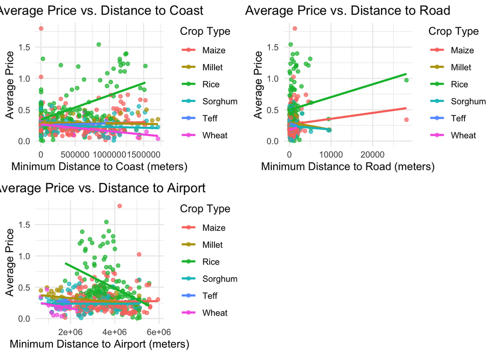

```r
# (i) Average Price vs. Minimum Distance to Coast
p_coast <- ggplot(sf.marketprices, aes(x = min_coast_dist, y = av_price, color = crop)) +
  geom_point(alpha = 0.7) +
  geom_smooth(method = "lm", se = FALSE) + # Add linear trend lines
  labs(
    title = "Average Price vs. Distance to Coast",
    x = "Minimum Distance to Coast (meters)",
    y = "Average Price",
    color = "Crop Type"
  ) +
  theme_minimal() +
  theme(
    plot.title = element_text(hjust = 0.5)
  )

# (ii) Average Price vs. Minimum Distance to Road
p_road <- ggplot(sf.marketprices, aes(x = min_road_dist, y = av_price, color = crop)) +
  geom_point(alpha = 0.7) +
  geom_smooth(method = "lm", se = FALSE) + # Add linear trend lines
  labs(
    title = "Average Price vs. Distance to Road",
    x = "Minimum Distance to Road (meters)",
    y = "Average Price",
    color = "Crop Type"
  ) +
  theme_minimal() +
  theme(
    plot.title = element_text(hjust = 0.5)
  )

# (iii) Average Price vs. Minimum Distance to Airport
p_airport <- ggplot(sf.marketprices, aes(x = min_airport_dist, y = av_price, color = crop)) +
  geom_point(alpha = 0.7) +
  geom_smooth(method = "lm", se = FALSE) + # Add linear trend lines
  labs(
    title = "Average Price vs. Distance to Airport",
    x = "Minimum Distance to Airport (meters)",
    y = "Average Price",
    color = "Crop Type"
  ) +
  theme_minimal() +
  theme(
    plot.title = element_text(hjust = 0.5)
  )

# Display the plots in a grid
grid.arrange(p_coast, p_road, p_airport, nrow = 2, ncol = 2)
```